# ggstackplot

2025-01-31

```r
# load the package
library(ggstackplot)
```

This vignette explores the various features of the ggstackplot package.

# Main Arguments

## `x` and `y` arguments

### Vertical stack

Select variables to make a stack. The selection order translates to the order with which the plots are stacked. Any valid tidyselect selection and/or renaming are supported.

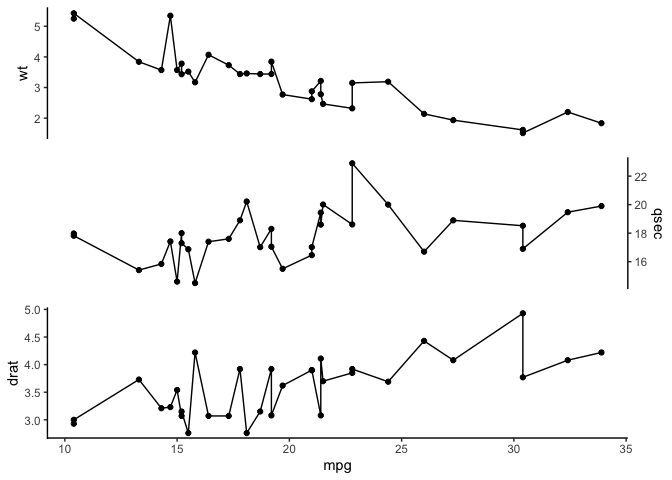

```r
# select any number of variables to make the stack
mtcars |>
  ggstackplot(
    x = mpg, y = c(wt, qsec, drat)
  )
```

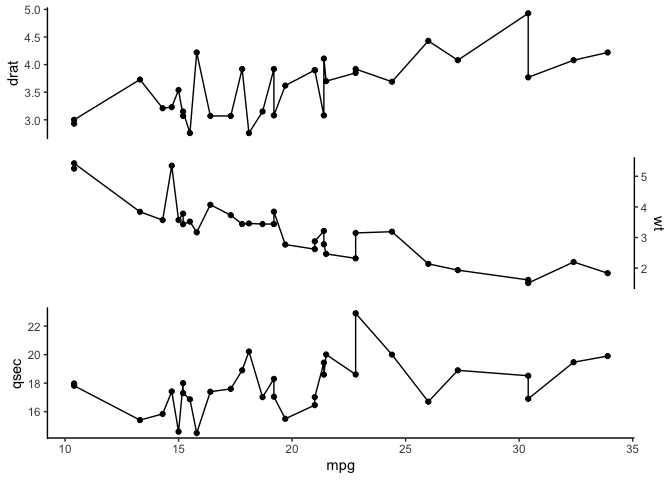

```r
# the selection order translates into stack order
mtcars |>
  ggstackplot(
    x = mpg, y = c(drat, wt, qsec)
  )
```

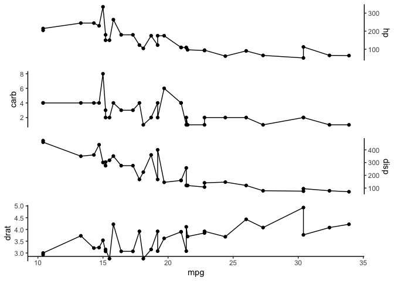

```r
# use any valid tidyselect selection syntax
mtcars |>
  ggstackplot(
    x = mpg, y = c(4, "carb", starts_with("d"))
  )
```

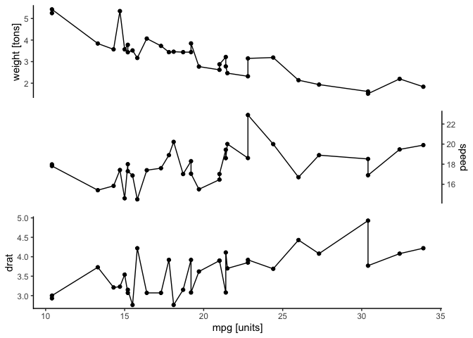

```r
# use any valid tidyselect renaming syntax to rename stack panels
mtcars |>
  ggstackplot(
    x = c(`mpg [units]` = mpg),
    y = c(`weight [tons]` = wt, `speed` = qsec, drat)
  )
```

### Horizontal stack

Select multiple x variables to stack:

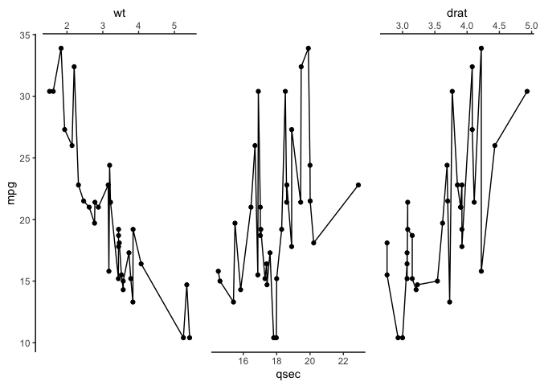

```r
# all examples shown in this document work the same way for a horizontal
# stack, simply switch out the x and y assignments
mtcars |>
  ggstackplot(
    y = mpg, x = c(wt, qsec, drat)
  )
```

## `palette` argument

Set individual plot colors by providing an RColorBrewer palette. Color definition applies to the color and fill aesthetics as well as the actual axis colors.

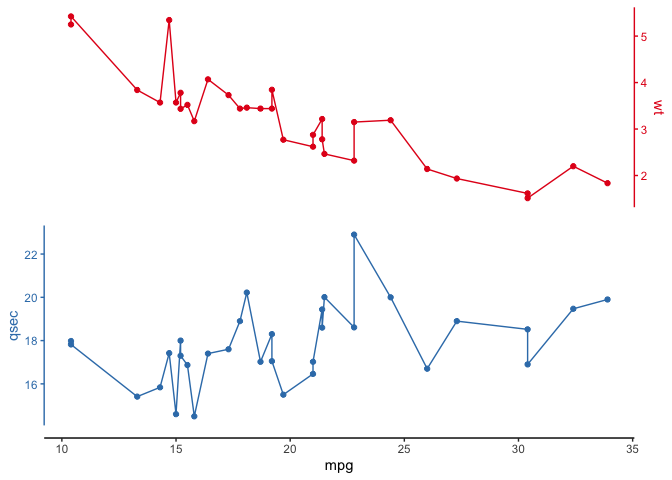

```r
# use the Set1 RColorBrewer palette
mtcars |>
  ggstackplot(
    x = mpg, y = c(wt, qsec),
    palette = "Set1"
  )
```

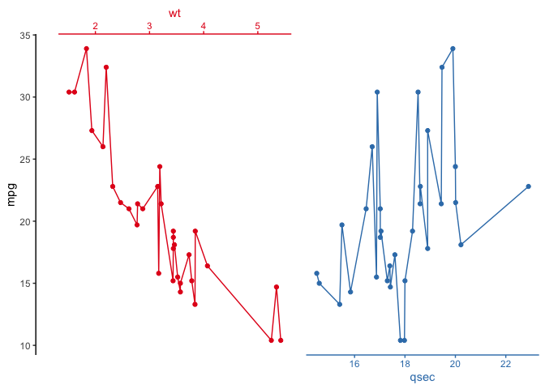

```r
# likewise for the horizontal stack version
mtcars |>
  ggstackplot(
    y = mpg, x = c(wt, qsec),
    palette = "Set1"
  )
```

## `color` argument

Alternatively, set colors manually by supplying a character vector of colors:

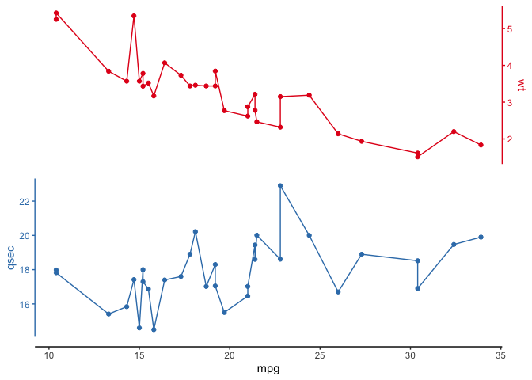

```r
# select any specific colors for each plot
mtcars |>
  ggstackplot(
    x = mpg, y = c(wt, qsec),
    color = c("#E41A1C", "#377EB8")
  )
```

## `remove_na` argument

This removes NA values so that lines are not interrupted. When `remove_na` is set to `FALSE`, breaks in lines may appear due to NA values.

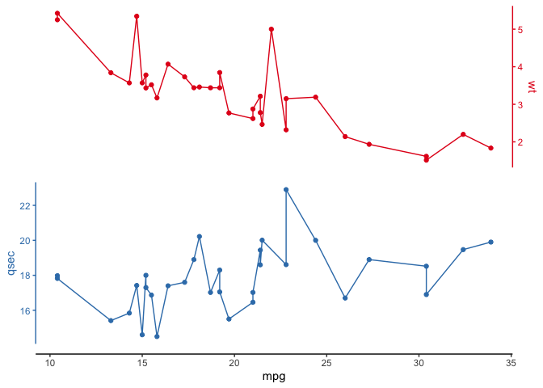

```r
library(dplyr)

# default (NAs are removed so lines are not interrupted)
mtcars |>
  add_row(mpg = 22, wt = 5, qsec = NA) |>
  ggstackplot(
    x = mpg, y = c(wt, qsec),
    color = c("#E41A1C", "#377EB8")
  )
```

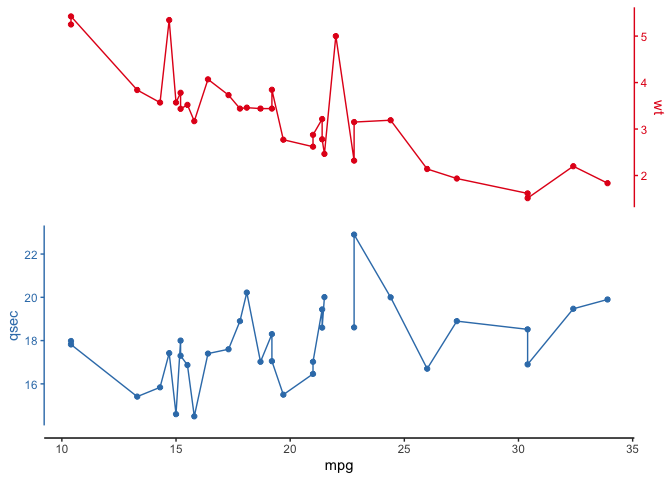

```r
# explicit `remove_na` = FALSE
mtcars |>
  add_row(mpg = 22, wt = 5, qsec = NA) |>
  ggstackplot(
    x = mpg, y = c(wt, qsec),
    color = c("#E41A1C", "#377EB8"),
    remove_na = FALSE
  )
```

## `both_axes` argument

When `both_axes = TRUE` , the stacked variable axes are duplicated on both sides of each stacked plot.

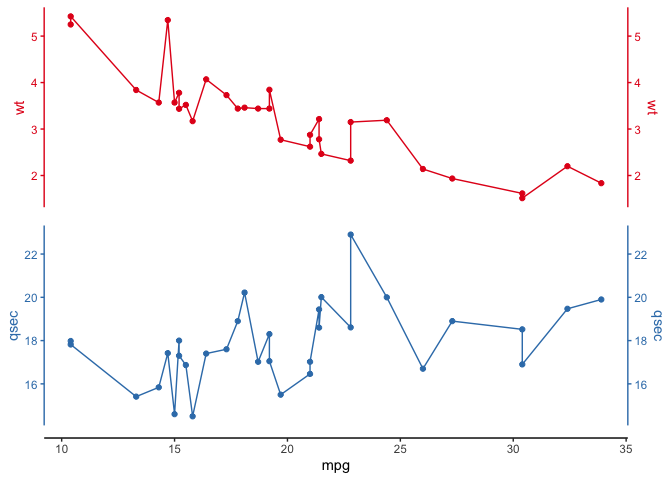

```r
# Vertical stackplot
mtcars |>
  ggstackplot(
    x = mpg, y = c(wt, qsec),
    color = c("#E41A1C", "#377EB8"),
    both_axes = TRUE
  )
```

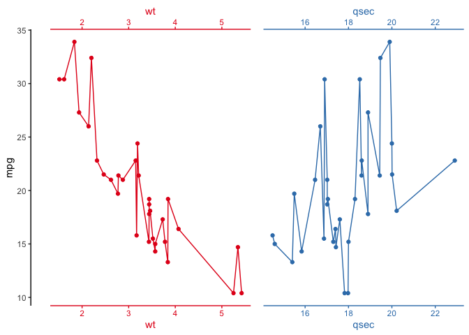

```r
# Horizontal stackplot
mtcars |>
  ggstackplot(
    y = mpg, x = c(wt, qsec),
    color = c("#E41A1C", "#377EB8"),
    both_axes = TRUE
  )
```

## `alternate_axes` argument

When `alternate_axes = FALSE` , the axes for the multiple variables are kept on the same side of the facets. The default behavior alternates these axes left/right or top/bottom.

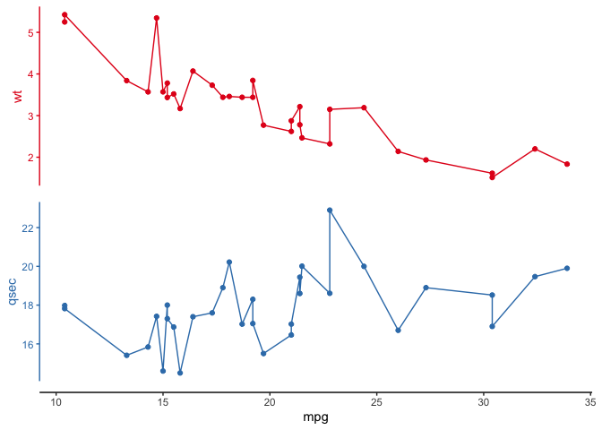

```r
# axes do not alternate:
mtcars |>
  ggstackplot(
    x = mpg, y = c(wt, qsec),
    color = c("#E41A1C", "#377EB8"),
    alternate_axes = FALSE
  )
```

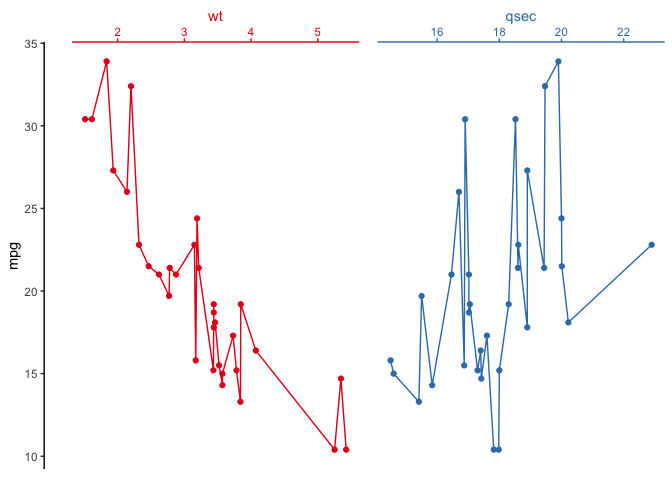

```r
# Horizontal version
mtcars |>
  ggstackplot(
    y = mpg, x = c(wt, qsec),
    color = c("#E41A1C", "#377EB8"),
    alternate_axes = FALSE
  )
```